# R Individual Project

Mona Zhu

## Project Background

For my individual project, I am analyzing some data obtained from previous graduate classes (e.g., ANOVA and Regression classes). The objective of the project was to examine how people’s seating behaviour changes as the course progresses. Specifically, we wanted to examine whether seating behaviour becomes increasingly more fixed with time. This will be the first part of the project.

Since individuals are picking seats in a context where they are interacting with other individuals, presumably, social factors such as people’s affiliation with one another may also influence where they choose to sit in class. While trying to uncover this relation may be beyond the scope of this project, the goal here is to try to take a stab at inferring social affiliation based solely on individuals’ seating behaviour using clustering/classification algorithms.

### Load libraries

```r
library(xlsx)
library(car)
library(plyr)
library(ggplot2)
library(reshape2)
library(lme4)
library(RColorBrewer)
library(plotly)
library(nlme)
library(mclust)
```

### Setting working directories, reading files & general organization

The full dataset we have obtained contain anonymized data from 4 different graduate classes. For the sake of simplicity, we will only be using data from one of those classes.

```r
setwd("//psychfile/psych$/psych-lab-efrisko/Mona/Classroom (new)")
dfp<-read.xlsx("Complete Classroom Data_Fixed (partial)_24Mar2017.xlsx", sheetName="Sheet1") # lecture days only
dfp$UserName=factor(round(dfp$UserName, 0))
df.w15<-subset(dfp, Year=="W2015")

sub<-subset(df.w15, Time!=1)
sub$Class=factor(sub$Class)
sub$Class=factor(sub$Class, levels(sub$Class)[c(1,3,2,4)])
sub$Condition=factor(sub$Condition)
sub$Condition=factor(sub$Condition, levels(sub$Condition)[c(2,1)])
```

This is a example of what the data look like:

```r
head(sub)
```

```
##   UserName    Machine  LogonDate SessionDuration Day Time Order ClassType
## 1  6270990 PAS1237-28 2015-01-14             155   2    8     4   Lecture
## 2  6270990 PAS1237-40 2015-01-21             157   3   15    17   Lecture
## 3  6270990 PAS1237-28 2015-01-28             122   4   22    14   Lecture
## 4  6270990 PAS1237-28 2015-02-04             127   5   29     6   Lecture
## 5  6270990 PAS1237-28 2015-02-25              85   6   50    11   Lecture
## 6  6270990 PAS1237-28 2015-03-04             135   7   57     3   Lecture
##   DistFromFirst DistFromPrev Condition  Year   Class
## 1            NA           NA    Chosen W2015 Lecture
## 2            NA     4.104096    Chosen W2015 Lecture
## 3            NA     4.104096    Chosen W2015 Lecture
## 4            NA     0.000000    Chosen W2015 Lecture
## 5            NA     0.000000    Chosen W2015 Lecture
## 6            NA     0.000000    Chosen W2015 Lecture
```

## Graphs & Analyses

This is a 3D visualization of the classroom data done using plotly, where the X- and Y- axes are the x and y coordinates and the Z-axis is time. (Feel free to click and drag your mouse on the graph to rotate the graph)

### 3D Graph

```r
dff<-read.xlsx("Complete Classroom Data_FULLDATA_21Mar2017.xlsx", sheetName="Sheet1") # full data set
dff$UserName=factor(round(dff$UserName, 0))
pos<-read.csv("Computer Location Coordinates.csv", header=T) # x/y cordinates of computers

cooked<-merge(dff, pos, by="Machine", all.x=T, all.y=F)
```

```r
w15<-subset(cooked, Year=="W2015" & Condition=="Chosen")
N<-length(unique(w15$UserName)) # 24 unique IDs
ID<-data.frame(UserName=levels(as.factor(as.character(w15$UserName))),
               col=c(brewer.pal(11, "Spectral"), brewer.pal(8, "Set2"), brewer.pal(5, "Pastel2")))

df.col<-merge(w15, ID, by="UserName", all.x=T, all.y=F)
df.col$col<-as.character(df.col$col)

plot_ly(df.col, x= ~x.cord, y= ~y.cord, z= ~LogonDate, color= ~UserName, colors= ~col)%>%
  add_markers() %>%
  layout(scene = list(xaxis = list(title = 'X Coordinates'),
                     yaxis = list(title = 'Y Coordinates'),
                     zaxis = list(title = 'Date')))
```

[interactive chart not shown]

### Seating Choice Over Time

To examine whether individuals’ seating choices stablized as a function of time, I ran a linear mixed-effects model using the *lmer* function in the *lme4* package. Since degrees of freedom is not provided by this function, any t-value greater than |2| would be considered a significant predictor.

The critical DV is how far people sat from their previous class. To do this, I calculated a difference score between the coordinate for their chosen seat for the current class and the previous class. This is the **DistFromPrev** factor in the data. The first day is trimmed from this data set as we cannot calculate a difference score for that day.

The critical IVs I wanted to examine are **Time** (measured in days rather than by date) and **Order**, which is the order that students arrived to class. This was approximated using the logon time stamp. The reason why I am including Order in my analysis is because the order of arrival can contrain people’s ability to pick desired seats (e.g., the later an individual arrives, the less seats they can pick from, and the more likely that their preferred seat gets taken by someone else).

Finally, **UserName**, or individual subjects, are modelled as a random variable.

For this (and subsequent) analysis, we excluded any days where an exam was held. This is because we found that some people would only show up on exam days, which would disrupt any seating preferences that may have been developed prior to that for people who show up regularly to lectures.

(Note: I ran the model with both the exam days included and excluded, and the overall pattern of results remained the same across)

```r
dfp.c<-subset(df.w15, Condition=="Chosen" & Time!=1) # All classes
m.part.prev<-lmer(DistFromPrev~Time+Order+(1|UserName), data=dfp.c)
coef(summary(m.part.prev))
```

```
##                Estimate  Std. Error   t value
## (Intercept)  1.09749156 0.305925117  3.587452
## Time        -0.01088863 0.004217581 -2.581724
## Order        0.06925388 0.019038336  3.637601
```

Based on this analysis, it appears that both *Time* and *Order* are significant predictors.

Below are some plots scatter plots to reflect those relations. The size of each dot represent the number of observations for that point.

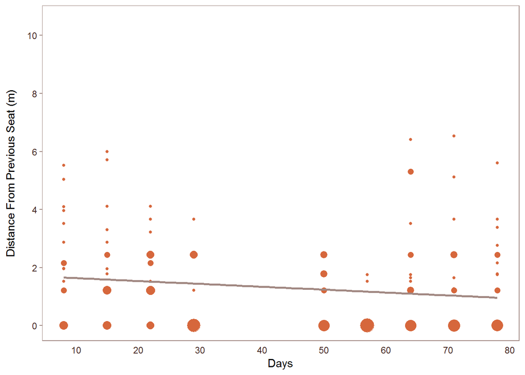

```r
# resizing points such that the size of each point represent number of observation
dfp.prev.time<-as.data.frame(table(dfp.c$Time, dfp.c$DistFromPrev))
names(dfp.prev.time)=c("Time", "DistFromPrev", "count")
dfp.prev.time.sum<-subset(dfp.prev.time, count>0)
dfp.prev.t<-merge(dfp.c, dfp.prev.time.sum, by=c("Time", "DistFromPrev"), all.x=T, all.y=F)

# graph
ggplot(dfp.prev.t, aes(x=Time, y=DistFromPrev, size = count, colour="blue")) +
  geom_point()+
  #ggtitle("Combined (Dist. From Initial)")+ # change title
  theme(# remove the background & grid altogether
    panel.background= element_rect(fill=NA),
    plot.background = element_rect(fill=NA, colour=NA),
    panel.grid=element_blank(),
    axis.ticks.x=element_blank(),
    axis.ticks=element_line(colour="#A18882"),
    panel.border = element_rect(fill="transparent", colour="#A18882"),
    legend.background = element_rect(fill = "transparent", colour = "transparent"),
    axis.text = element_text(color="#432620"),
    legend.position="none",
    axis.title.y=element_text(margin=margin(0,10,0,0)),
    axis.title.x=element_text(margin=margin(5,0,0,0)))+
  geom_smooth(method = lm, se=FALSE, fullrange=TRUE, colour="#A18882")+
  scale_y_continuous("Distance From Previous Seat (m)",  breaks=seq(0, 20, 2),
                     limits=c(0, 10.5))+
  scale_x_continuous("Days", breaks=seq(0, 100, 10))+
  scale_color_manual(values="#D6673C")
```

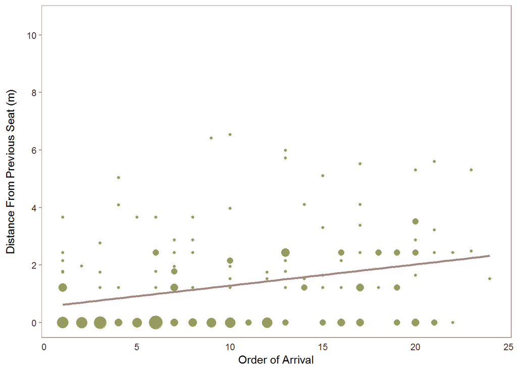

```r
# doing the same thing for order
dfp.prev.ord<-as.data.frame(table(dfp.c$Order, dfp.c$DistFromPrev))
names(dfp.prev.ord)=c("Order", "DistFromPrev", "count")
dfp.prev.ord.sum<-subset(dfp.prev.ord, count>0)
dfp.prev.o<-merge(dfp.c, dfp.prev.ord.sum, by=c("Order", "DistFromPrev"), all.x=T, all.y=F)


ggplot(dfp.prev.o, aes(x=Order, y=DistFromPrev, size=count, colour="blue")) +
  geom_point()+
  #ggtitle("Combined (Dist. From Initial)")+ # change title
  theme(# remove the background & grid altogether
    panel.background= element_rect(fill=NA),
    plot.background = element_rect(fill=NA, colour=NA),
    panel.grid=element_blank(),
    axis.ticks.x=element_blank(),
    axis.ticks=element_line(colour="#A18882"),
    panel.border = element_rect(fill="transparent", colour="#A18882"),
    legend.background = element_rect(fill = "transparent", colour = "transparent"),
    axis.text = element_text(color="#432620"),
    legend.position="none",
    axis.title.y=element_text(margin=margin(0,10,0,0)),
    axis.title.x=element_text(margin=margin(5,0,0,0)))+
  geom_smooth(method = lm, se=FALSE, fullrange=TRUE, colour="#A18882")+
  scale_y_continuous("Distance From Previous Seat (m)",  breaks=seq(0, 20, 2),
                     limits=c(0, 10.5))+
  scale_x_continuous("Order of Arrival")+
  scale_color_manual(values="#969C60")
```

## Social Affiliation

The other component of this project is to attempt to use clustering algorithms to infer information about people’s affiliation with one another.

First, I created a matrix that included all possible pairs of seats/dyads on a given day and the distance between them.

```r
cooked.p<-merge(df.w15[df.w15$Condition=="Chosen",], pos, by="Machine", all.x=T, all.y=F)
# matrix creation
data<-NULL

id<-unique(as.character(cooked.p$UserName)) # unique IDs
date<-levels(as.factor(cooked.p$LogonDate)) # unique dates

for(d in date){
  sub<-cooked.p[cooked.p$LogonDate==d, ]
  for (i in id){
    sub[,i]<-sqrt((sub$x.cord-sub$x.cord[sub$UserName==i])^2+(sub$y.cord-sub$y.cord[sub$UserName==i])^2)
  }
  data=rbind(data, sub)
}
```

The matrix looks something like this:

```r
data[1:5,c(2,15:19)]
```

```
##    UserName 56383067 36127821 51966972 23495048 86860380
## 9  51966972 1.220000 2.440000 0.000000 6.417225 4.347318
## 12 56383067 0.000000 3.660000 1.220000 5.738778 3.263737
## 22 62403463 2.490000 6.150000 3.710000 5.033793 1.748564
## 32 83079659 3.710000 7.370000 4.930000 5.113147 1.965369
## 56 86860380 3.263737 6.657625 4.347318 3.300000 0.000000
```

Next, I ran some clustering/classification algorithms on the distance between pairs of subjects. I used two different methods to do this. First, I used a model-based clustering package called *mclust*, which doesn’t make any assumptions about how many categories/clusters there are in the data. One downside to using this method is that the outcome can overfit the data.

The other method is to cluster a set of data points based on a pre-determined number of categories. This was done using the *kmeans* function. I set the pre-determined cateroty number to **2** to delineate between dyads who are (more likely to be) friends vs. acquaintances.

```r
melted<-melt(data, id=c(1:14))
names(melted)[c(15,16)]=c("Pair", "PairDiff")
melted$Dyads<-paste0(melted$UserName, "-", melted$Pair)

new<-melted[complete.cases(melted$PairDiff),]
new<-subset(new, PairDiff>0)
new<-new[order(new$PairDiff),]
rownames(new) = c(1:nrow(new))

cluster<-NULL

for(d in date){
  day<-subset(new, LogonDate==d)
  kclust<-kmeans(day$PairDiff, 2, nstart=100)
  mclustr<-Mclust(day$PairDiff)
  frame<-data.frame(LogonDate=d,
                    Dyads=day$Dyad,
                    M.Classification=mclustr$classification,
                    CenterDiff=kclust$centers[2]-kclust$centers[1],
                    K.Classification=kclust$cluster)
  cluster<-rbind(cluster, frame)
}
```

Note: While the *MClust* function classifies categories from smallest to largest (e.g., if 4 categories are created, the category labelled “1” would have the smallest mean and the category labelled “4” would have the largest mean), this is not the case for the *kmeans* function, thus the categories need to be corrected.

```r
# make sure classification are all in the same direction
cluster$K.Classification<-ifelse(cluster$CenterDiff<0, 3-cluster$K.Classification,
                               cluster$K.Classification)

new$Dyads=factor(new$Dyads)
data2<-merge(new, cluster, by=c("LogonDate", "Dyads"), all.x=F, all.y=T)
```

### Results & Visualization

Below are some stats on the categories made based on the k-means cluster analysis:

```r
ddply(data2, .(K.Classification), function(df)
  return(c(Min=min(df$PairDiff), Max=max(df$PairDiff),Average=mean(df$PairDiff, na.rm=T))))
```

```
##   K.Classification     Min       Max  Average
## 1                1 1.22000  4.460789 2.823914
## 2                2 4.77509 11.122589 6.531717
```

The *Mclust* package produced on average 4.6 categories (ranging from 3 to 7), which may suggest that the algorithm is overfitting the data.

```r
Mod.Based<-as.data.frame(as.matrix(tapply(data2$M.Classification, data2$LogonDate, max)))
names(Mod.Based)[1]<-"Cluster.Size"
Mod.Based
```

```
##            Cluster.Size
## 2015-01-07            5
## 2015-01-14            7
## 2015-01-21            3
## 2015-01-28            5
## 2015-02-04            5
## 2015-02-25            3
## 2015-03-04            5
## 2015-03-11            5
## 2015-03-18            4
## 2015-03-25            4
```

Here is a visual representation of where the clusters fall on each day. The teal line delineates where the k-means clustering algorithm separates the two categories.

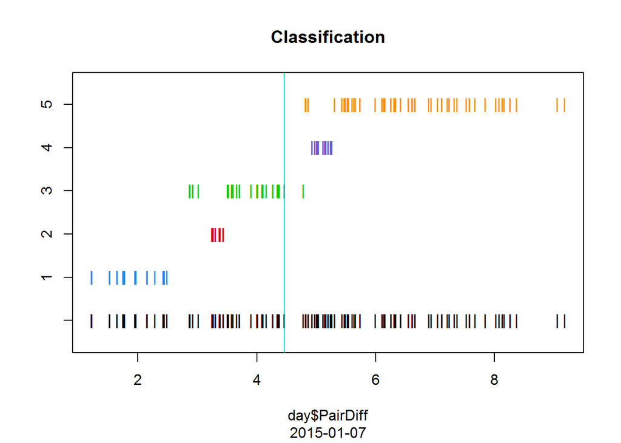

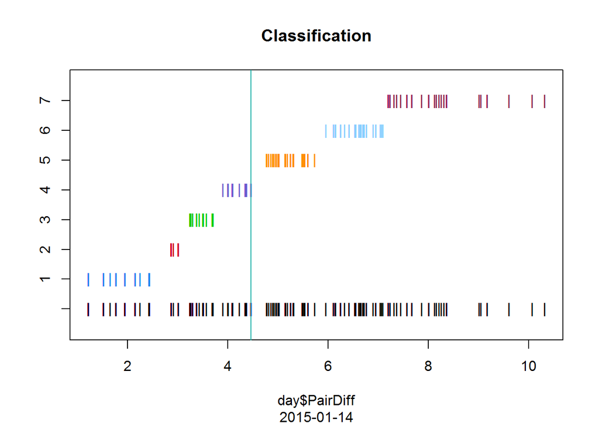

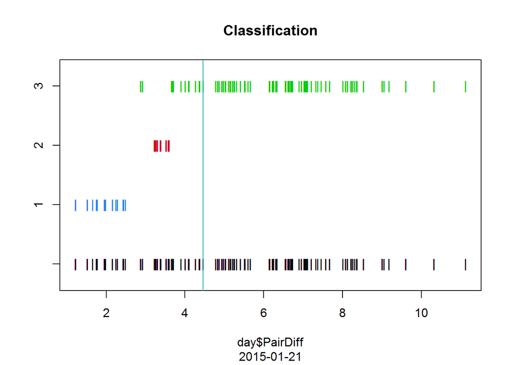

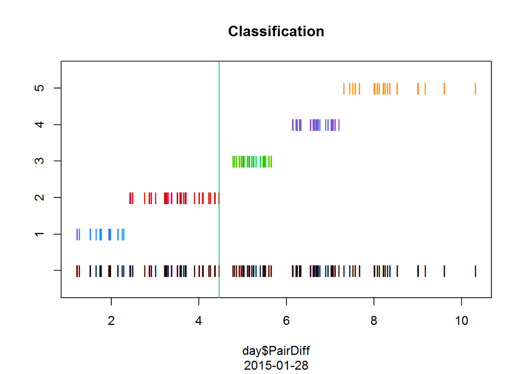

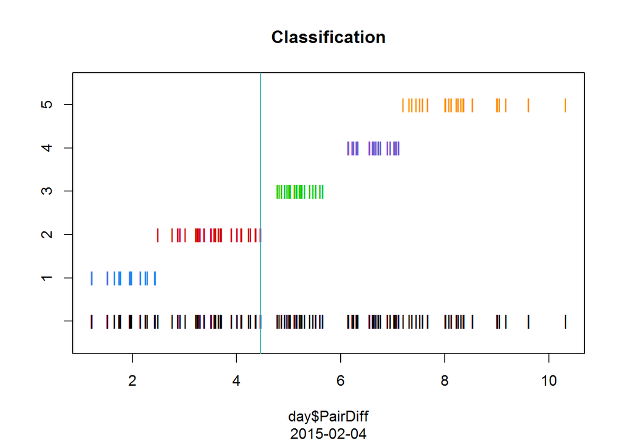

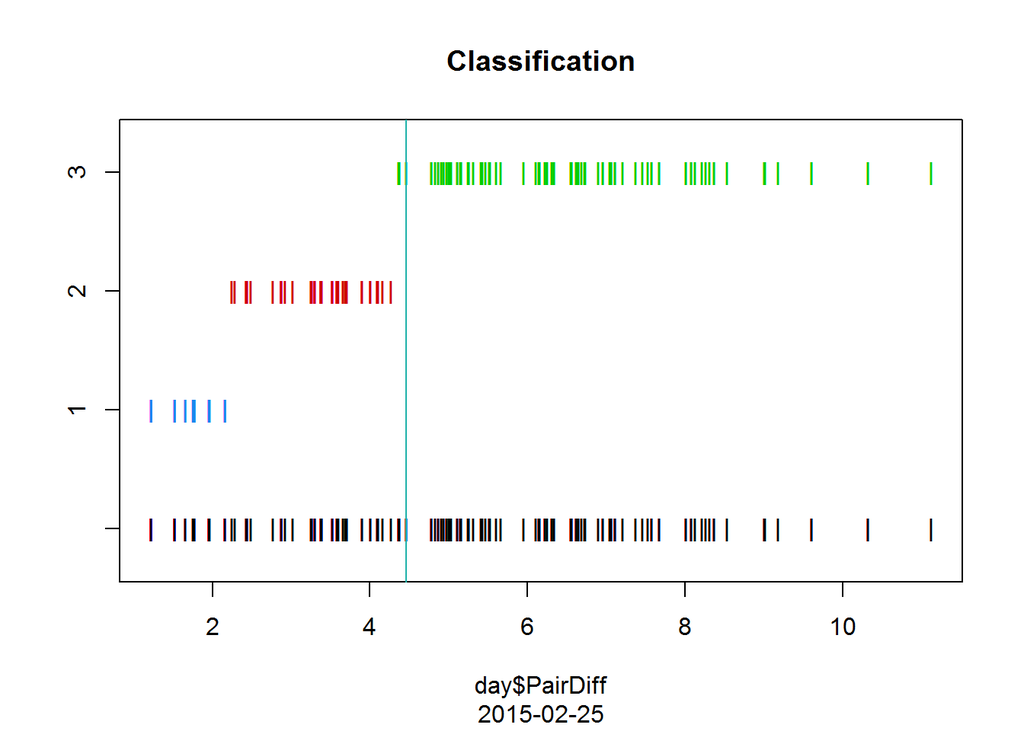

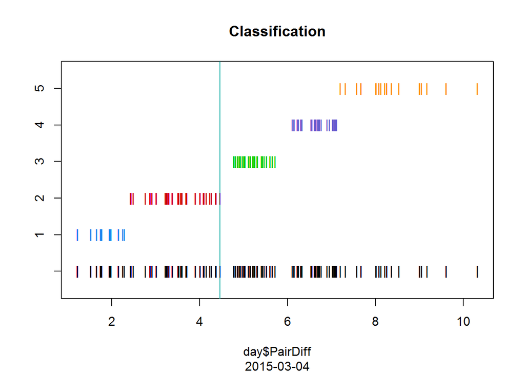

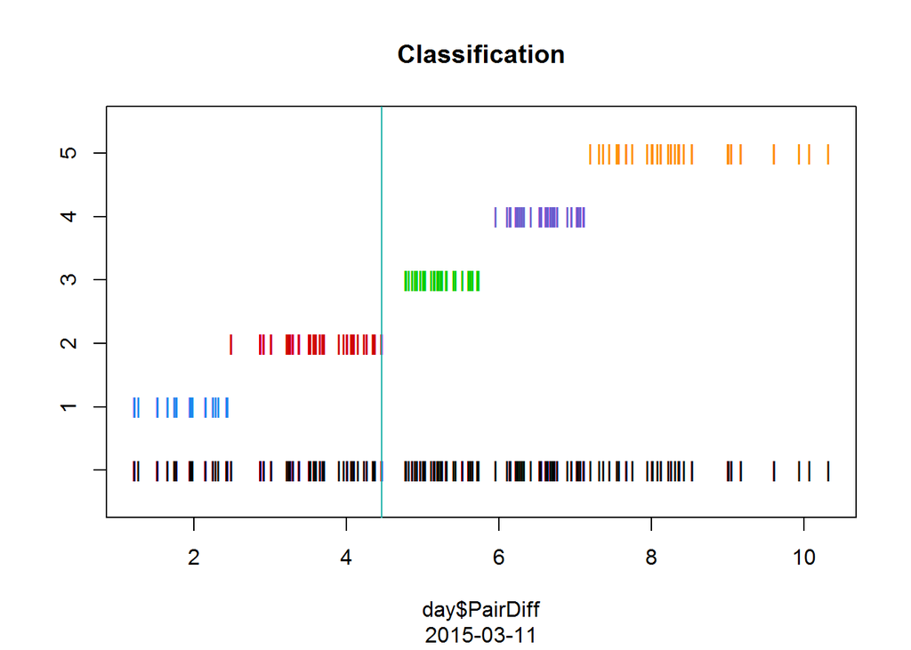

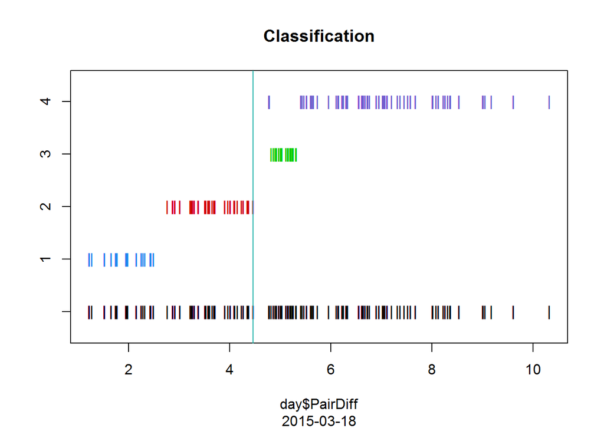

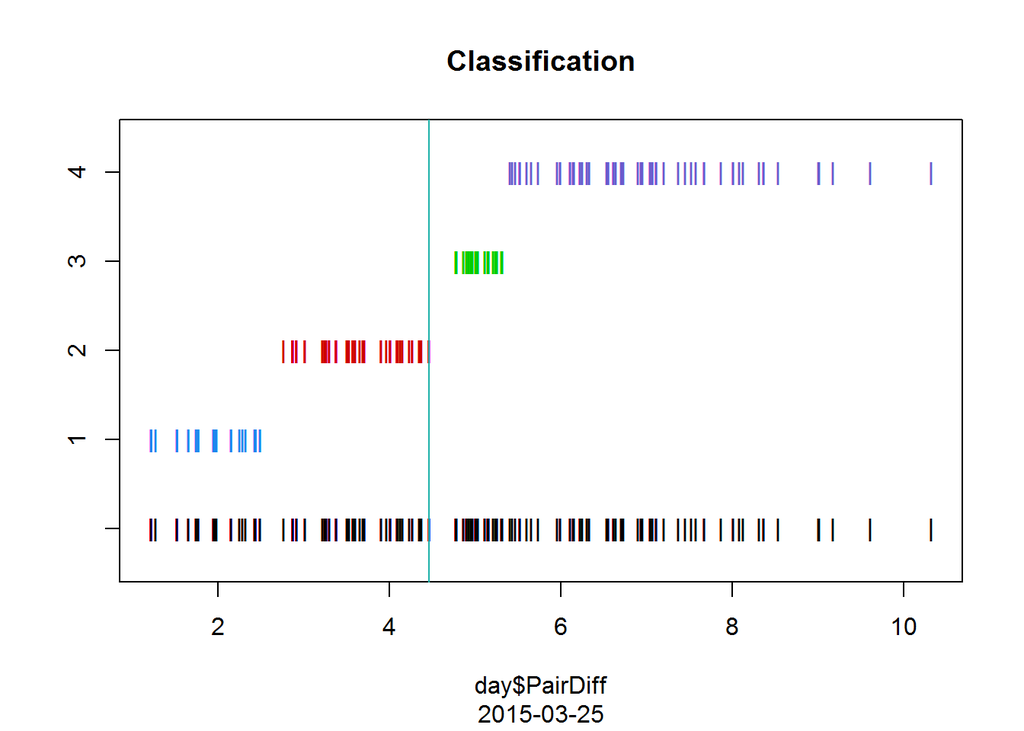

```r
for(d in date){
  day<-subset(data2, LogonDate==d)
  mclustr<-Mclust(day$PairDiff)
  plot(mclustr, what = "classification")
  abline(v=max(day[day$K.Classification=="1",]$PairDiff), col="lightseagreen")
  title(sub=d)
}
```